# Predicting Student Dropouts

Final Project Report  
Data Science 2 with R (STAT 301-2)

Author

Jessie Chen

Published

March 13, 2024

**Github Repo Link**

[My Repo Link](https://github.com/stat301-2-2024-winter/final-project-2-Jchench.git)

## Introduction

### Prediction Problem

The prediction problem that I am focusing on for this project is a **classification problem** and I’m looking to identify whether or not a student has dropped out of college at the end of a school year (2 semesters). I think having this prediction model would be useful for this problem because it will also help indicate factors that might make a student more at risk of dropping out.

The target variable we are looking at identifies a student’s academic status, which has three classes indicating whether a student is currently enrolled, graduated, or has dropped out of college.

### Data source

The [dataset](https://archive.ics.uci.edu/dataset/697/predict+students+dropout+and+academic+success) that I’m using is from UC Irvine’s Machine Learning Repository. This dataset was created by a number of authors, using information from higher education institution (acquired from several disjoint databases) related to students enrolled in different undergraduate degrees. [^1]

*This data was mainly taken from schools in Portugal.

## Data overview & quality

The dataset includes 37 variables in total: 16 categorical variables and 21 numeric variables. This dataset also has 4424 observations with each one representing a student.

### Inspection of missingness and class imbalance:

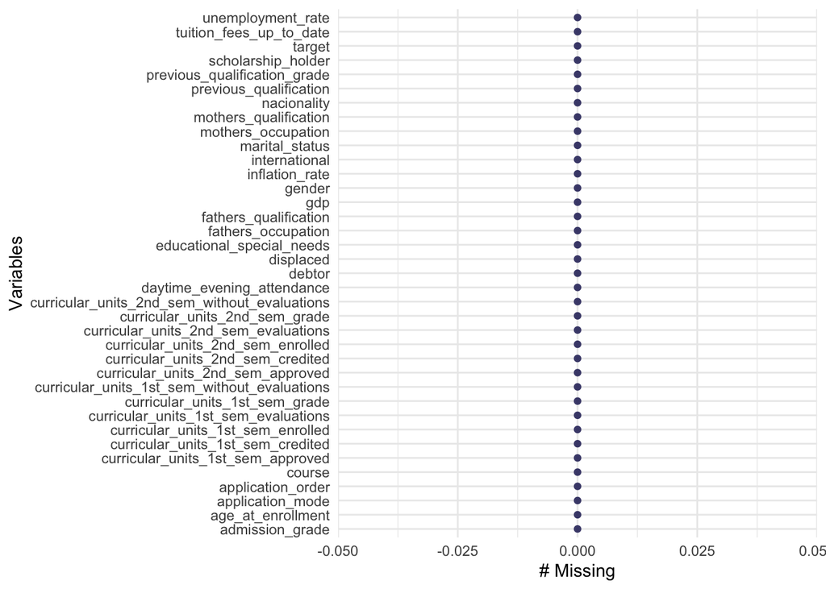

Figure 1: Number of missing values for each variable

As we can see from Figure 1, there are fortunately no missing values for variables in this dataset.

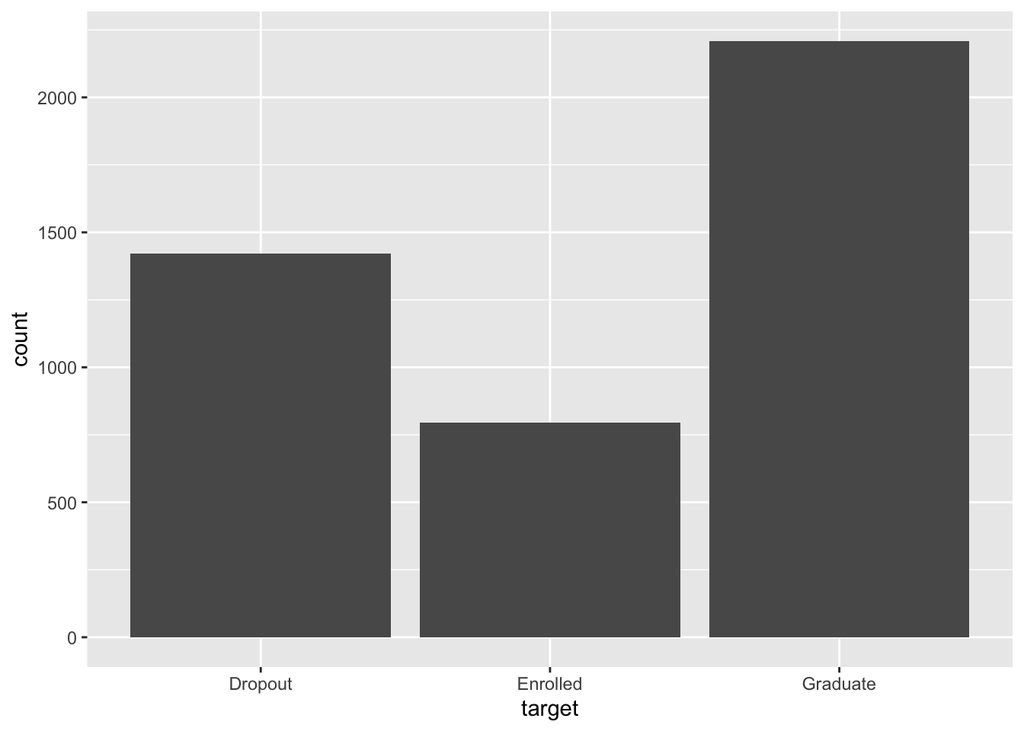

Figure 2: Distribution of classes within the target variable

We can see from Figure 2, the distribution of the target variable is relatively imbalanced with significantly more students graduating compared to dropping out or currently enrolling. Thus, it would be helpful to use strata when splitting the data into training and learning.

### Conclusions from EDA

The main insights that can be generated from the EDA are that there is a pretty strong positive correlation between admission grade and previous qualification grade. This means that students who were doing well academically before college also tend to do well academically during college. Curricular units grades from the first semester are pretty positively correlated with curricular units grades from the second semester as well. This suggests that there could be possible interactions between the number of curricular units approved and grade earned for a student’s first and second semester. Additionally, variables that would be important to look at are a student’s gender, debtor status, whether or not their tuition is up to date, and whether or not they are a scholarship holder.

*A more detailed EDA for the training dataset is in Appendix I: EDA

## Methods

The prediction problem I’m looking at is **classification**, so I will be using the **ROC AUC** metric to evaluate my results. My target variable also has quite a bit of class imbalance and has more than two factor levels, which makes **ROC AUC** a more optimal metric because it measures both sensitivity and specificity and accounts for type I and type II errors.

### Data splitting and resampling procedure

Since my dataset has around 4424 observations, which is on the smaller end. I did a 75-25 split so that we can get more consistent and reliable estimates without running into issues of overfitting. This means that there will be around 3316 observations in the training dataset and 1108 observations in the testing dataset.

I also used vfold cross-validation to resample the training data. I used 5 partitions (v = 5) and 10 repeats since my dataset isn’t incredibly large. Resampling measures the average performance across all these partitions, and thus would allow me to get better estimates and also preventing overfitting.

### Model types and recipes:

Since my prediction problem is a **classification** problem, I plan on using these models

- **Naive Bayes (baseline model)**: I am using it as a benchmark to help me ultimately decide whether building complex models would be worth the effort. This model has no tuning parameters and will only be built with the baseline kitchen sink recipe.
- **Multinomial (because my target variable has 3 factor levels)**: This model is a classification method that generalizes logistic regressions to classification problems with more than 2 classes. This model does not require tuning and two variations will be built using both the kitchen sink and feature-engineered recipes.
- **Elastic Net**: This model is a regression added with a mixture and penalty term (lasso and ridge). This model requires tuning for the mixture and penalty terms and two variations will be built using both the kitchen sink and feature-engineered recipes.
- **K-Nearest Neighbor**: This is a non-parametric model that uses proximity to make predictions. This model requires tuning for the number of neighbors and two variations will be built using both the kitchen sink and feature-engineered recipes.
- **Random Forest**: This is a non-parametric model that combines the results of multiple decision trees to reach a prediction. This model requires tuning for the number of predictors and minimum number of data points in a node required before splitting. Two variations will be built using both the kitchen sink and feature-engineered recipes.
- **Boosted Tree**: This is a non-parametric model that is similar to the Random Forest model but it also considered errors made by previous decision trees. This model requires tuning for number of predictors, minimum number of data points in a node required before splitting, and learn rate. Two variations will be built using both the kitchen sink and feature-engineered recipes.

The two recipes I will use are a kitchen sink baseline and another one that is feature engineered according to my EDA conclusions.

#### Baseline recipe includes:

- Predict the target variable with all other variables
- Remove ID/ non-relevant variables like application order and application mode
- Encode categorical predictors (for parametric models, not applicable for Naive Bayes)
  - One-hot = TRUE (for tree-based models)
- Filter out variables have have zero variance
- Center & scale all predictors

#### Feature-engineered recipe includes:

- Predict the target variable with father’s qualification, mother’s qualification, admission grade, previous qualification grade, gender, debtor status, scholarship status, first semester curricular units grade, and second semester curricular units grades
- Encode categorical predictors
  - One-hot = TRUE (for tree-based models)
- Add interactions for (only for parametric models)
  - admission grade and previous qualification grade
  - father’s qualification and mother’s qualification
  - first semester curricular units grade and second semester curricular units grades
- Filter out variables have have zero variance
- Center & scale all predictors
- Filter out variables that have large or absolute correlations with other variables (for tree-based models)

## Model Building & Selection

**Evaluation Metric**

The metric that I used to evaluate the performance of these models is **ROC AUC**. The closer the ROC AUC value of a model is to 1, the better it performed.

### Analysis of ROC AUC results

Table 1: Model result ROC AUC comparisons

| model | .metric | mean | std_err |
| --- | --- | --- | --- |
| boosted tree | roc_auc | 0.8707153 | 0.0017523 |
| random forest | roc_auc | 0.8702948 | 0.0018368 |
| elastic net | roc_auc | 0.8687724 | 0.0019554 |
| multinomial | roc_auc | 0.8412154 | 0.0022390 |
| naive bayes | roc_auc | 0.8229426 | 0.0021640 |
| boosted tree2 | roc_auc | 0.7863092 | 0.0025562 |
| random forest2 | roc_auc | 0.7844966 | 0.0023517 |
| elastic net2 | roc_auc | 0.7778591 | 0.0022695 |
| multinomial2 | roc_auc | 0.7624022 | 0.0025680 |
| k nearest neighbor | roc_auc | 0.7278431 | 0.0022041 |
| k nearest neighbor2 | roc_auc | 0.7157141 | 0.0026870 |

As we can see from Table 1, the boosted tree model performed the best because it has a ROC AUC value that is closest to 1. This means that it has pretty good sensitivity and specificity (low false positive rate). We can also see that models that used the kitchen sink baseline recipe typically performed better than the models that used the feature engineered recipe (end with suffix 2).

### Brief Tuning Parameter Analysis:

Here are the tuning parameters that produced the best ROC AUC values for each model:

* More detailed plot analyses in Appendix II

For the KNN model, there was only 1 parameter that required tuning:

Table 2: Best KNN Tuning Parameters

| neighbors | .config |
| --- | --- |
| 15 | Preprocessor1_Model5 |

As we can see from Table 2, the best tuning parameter for the number of neighbors is 15 for the KNN model built with the baseline kitchen sink recipe.

Table 3: Best KNN Tuning Parameters (Feature-Engineered)

| neighbors | .config |
| --- | --- |
| 15 | Preprocessor1_Model5 |

As we can see from Table 2, the best tuning parameter for the number of neighbors is also 15 for the KNN model built with the feature-engineered recipe.

For the Elastic Net model, there were 2 parameters that required tuning:

Table 4: Best Elastic Net Tuning Parameters

| penalty | mixture | .config |
| --- | --- | --- |
| 0.01 | 0.5 | Preprocessor1_Model11 |

Table 5: Best Elastic Net Tuning Parameters (Feature-Engineered)

| penalty | mixture | .config |
| --- | --- | --- |
| 0.01 | 0.5 | Preprocessor1_Model11 |

For the Random Forest model, there were 2 parameters that required tuning:

Table 6: Best Random Forest Tuning Parameters

| mtry | min_n | .config |
| --- | --- | --- |
| 57 | 8 | Preprocessor1_Model12 |

As we can see from Table 6, the best tuning parameter for the number of predictors that will be randomly sampled at each split is 57 and the minimum number of data points in a node for each split is 8.

Table 7: Best Random Forest Tuning Parameters (Feature-Engineered)

| mtry | min_n | .config |
| --- | --- | --- |
| 16 | 40 | Preprocessor1_Model22 |

As we can see from Table 7, the best tuning parameter for the number of predictors that will be randomly sampled at each split is 16 and the minimum number of data points in a node for each split is 40.

For the Boosted Tree model, there were 3 parameter that required tuning:

Table 8: Best Boosted Tree Tuning Parameters

| mtry | min_n | learn_rate | .config |
| --- | --- | --- | --- |
| 225 | 15 | 0.6309573 | Preprocessor1_Model125 |

Table 9: Best Boosted Tree Tuning Parameters

| mtry | min_n | learn_rate | .config |
| --- | --- | --- | --- |
| 16 | 11 | 0.0398107 | Preprocessor1_Model082 |

In conclusion, these were the tuning parameters that generated the best model results. For the parametric models, the hyperparameters were mostly quite similar for both recipes. I think further tuning could be explored particularly with the tree-based models in terms of the number of trees since I left that argument as the default.

## Final Model Analysis

The best performing model was the Boosted Tree model built with the baseline recipe, so I fitted it to the training dataset. Here are my results after testing it against the testing dataset:

### ROC AUC Analysis

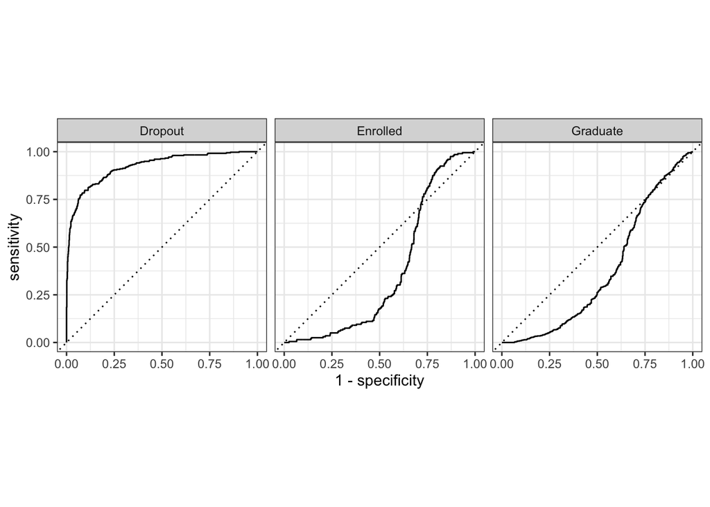

Figure 3: Final model ROC AUC result

As we can see from Figure 3, the ROC AUC curve for the dropout class is pretty good. It’s mostly above the random classifier line, which means that the predictions from the model are at least better than random guesses (0.5). The ROC AUC curve for the other two classes are not as good. In particular for the regions where specificity is less than 0.75, sensitivity is also quite low and the predictions tend to be worse than random guesses. Since I’m mainly focused on looking at dropout predictions, I’m not too concerned with how badly the model performed in predicting the other two classes. However, there definitely is room for improvement.

### Accuracy

Table 10: Final model accuracy result

| .metric | .estimator | .estimate |
| --- | --- | --- |
| accuracy | multiclass | 0.7951264 |

As we can see from Table 10, the accuracy for the final model is around 0.795. This means that the model was able to predict around 79.5% of the true values in the testing dataset.

### Confusion Matrix

Table 11: Final model confusion matrix

|  | Dropout | Graduate | Enrolled |
| --- | --- | --- | --- |
| Dropout | 279 | 14 | 50 |
| Graduate | 39 | 515 | 62 |
| Enrolled | 38 | 24 | 87 |

The confusion matrix (Table 11) calculates observed and predicted classes. In this case, the matrix shows the number of dropouts, graduates, and currently enrolled students that the model predicted, along with false positives and negatives. The quadrant Dropout, Dropout corresponds to when the model correctly predicted the number of dropout, which is 279 times.

There are also a couple quadrants that indicate false positives. The quadrant Dropout, Graduate corresponds to the number of times the model predicted a student had dropped out when they actually graduated, which is 14 times. The quadrant Dropout, Enrolled corresponds to the number of times the model predicted a student has dropped out when they actually are still enrolled, which is 50 times.

There are also a couple of quadrants that indicate false negatives. The quadrant Graduate, Dropout corresponds to the number of times the model predicted a student had graduated when they actually dropped out, which is 39 times. The quadrant Enrolled, Dropout corresponds to the number of times the model predicted a student was enrolled when they actually dropped out, which is 38 times.

Overall, the model seemed to do pretty well at predicting the number of true dropouts and true graduates, which is a good sign since the class I’m mainly concerned with predicting accurately is the dropout class.

## Conclusion

In conclusion it seems that the boosted tree model paired with the baseline kitchen sink recipe performed the best when predicting whether or not a student has dropped out of college (around 79.5% accurate). I think a lot of improvements could also be made in terms of my recipes. Since my feature engineered recipe didn’t necessarily work as well as my kitchen sink baseline recipe, I think I could do some more in-depth exploratory data analysis with all of the categorical variables in order to figure out which variables could be removed. I could have also done a bit more tuning for some of my models, particularly the tree-based ones since I left the number of trees the default.

## References

Dataset:

Realinho,Valentim, Vieira Martins,Mónica, Machado,Jorge, and Baptista,Luís. (2021). Predict students’ dropout and academic success. UCI Machine Learning Repository. https://doi.org/10.24432/C5MC89.

## Appendix I: EDA

Since my dataset isn’t very large, I’m going to perform an EDA on my training dataset to see if there are any insights that can be generated to inform my recipe steps.

### Numeric variables:

First, I’ll look at a correlation matrix across my numeric variables:

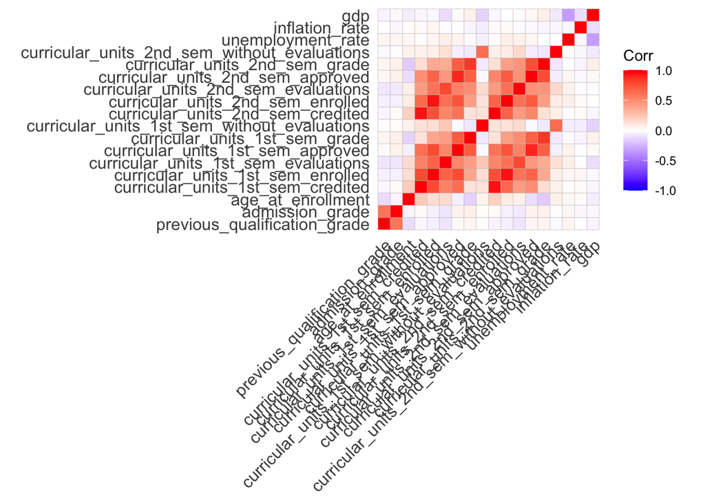

Figure 4: Correlation coefficient plot with numeric variables

As shown in Figure 4, some of the main insights that can be generated are that there is a strong negative relationship between gdp and unemployment rate. However, I personally don’t think that these are important variables to look at since they mostly pertain to the national economy rather than individual students (I might not include them in the recipe). There is also a pretty strong positive correlation between admission grade and previous qualification grade. This means that students who were doing well academically before college also tend to do well academically during college. The number of curricular units approved and curricular unit grades for a student from the first semester is also pretty positively correlated with the curricular units approved and curricular unit grades from the second semester. This suggests that there could be possible interactions between the number of curricular units approved and grade earned for a student’s first and second semester.

### Parents’ Education level:

Next, I decided to look at parents’ education level:

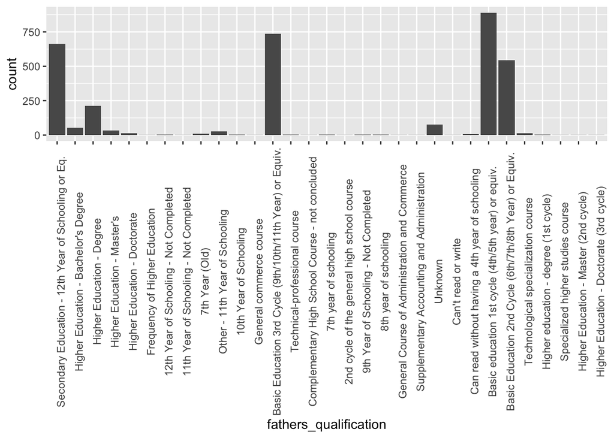

Figure 5: Distribution of student’s father’s highest level of education

As we can see from Figure 5, most student’s fathers seem to have an education level of “basic education 1st cycle” (4 - 5 years of schooling). This is followed by “basic education 3rd cycle” (9 - 11 years of schooling) and “secondary education” (12 years of schooling).

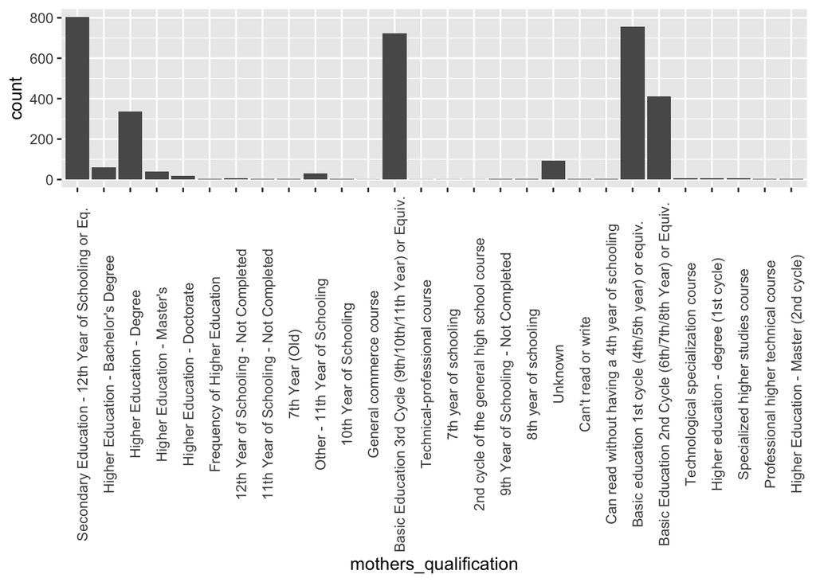

Figure 6: Distribution of student’s mother’s qualifications

As we can see from Figure 6, most student’s mothers seem to have an education level of “secondary education” (12 years of schooling). This is followed by “basic education 1st cycle” (4 - 5 years of schooling) and “basic education 3rd cycle” (9 - 11 years of schooling).

In general, the distribution of education level for a student’s father and mother are pretty similar. This suggests that there are possible interactions between these two variables.

### Gender:

Next, I decided to look at gender and whether or not it is correlated with the target variable:

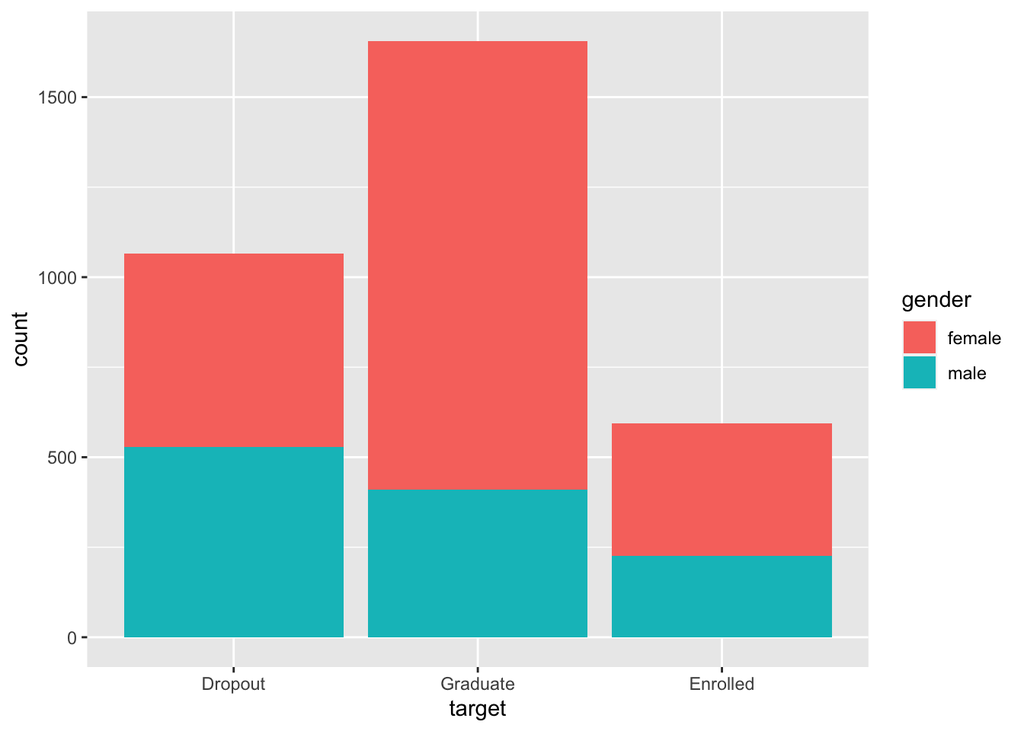

Figure 7: Gender and the target variable

Figure 7 shows that there are a couple of discrepancies in the gender proportion between these three target outcomes. It looks like a larger proportion of female students tend to graduate and are enrolled compared to male students. It also looks like the gender distribution for dropping out is pretty evenly split.

### Socio-economic class:

Next, I looked at variables that were indicative of socio-economic class:

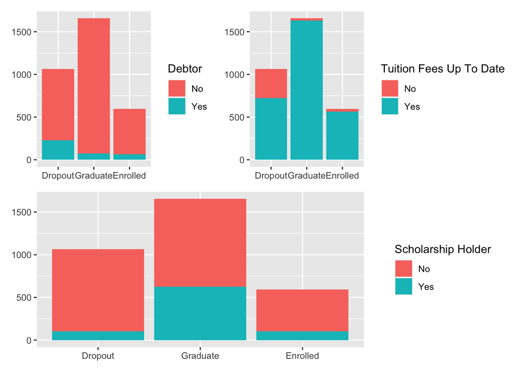

Figure 8: Socio-economic class analysis

Figure 8 shows that variables related to socio-economic class are also correlated to whether or not a student drops out of college. For example, a larger number of students who were debtors tended to be in the dropout category compared to the graduate and enrolled categories. The dropout category also had a greater proportion of students who don’t have their tuition fees up to date compared to students who have their fees up to date. It also looks like a larger proportion of students who are not scholarship holders tend to drop out compared to students who are scholarship holders.

### Insights for feature-engineering:

After performing a short EDA, I plan on creating a recipe that removes unrelated variables such as unemployment rate, GDP, and inflation (wasn’t really correlated with any other variables). A couple variables that would be important to look at are a student’s gender, debtor status, whether or not their tuition is up to date, and whether or not they are a scholarship holder. I also plan on creating interaction variables between first semester curricular units and second semester curricular units, admission grade and previous qualification grade, and father and mother’s qualifications. I also plan to add a recipe step to potentially remove variables that have large absolute correlations with other variables for my tree-based models.

## Appendix II: tuning parameter analysis

The models that need tuning are: K-Nearest Neighbor, Elastic Net, Random Forest, and Boosted Tree.

### K-Nearest Neighbor tuning parameters:

Let’s take a look at the tuning parameters for the KNN model:

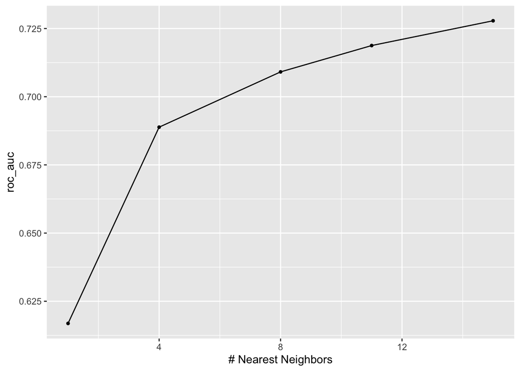

Figure 9: KNN Autoplot

As we can see from Figure 9, the ROC AUC value for the KNN model increases as the number of nearest neighbors increases. This means that the best tuning parameters would have a number of nearest neighbors that is more than 12.

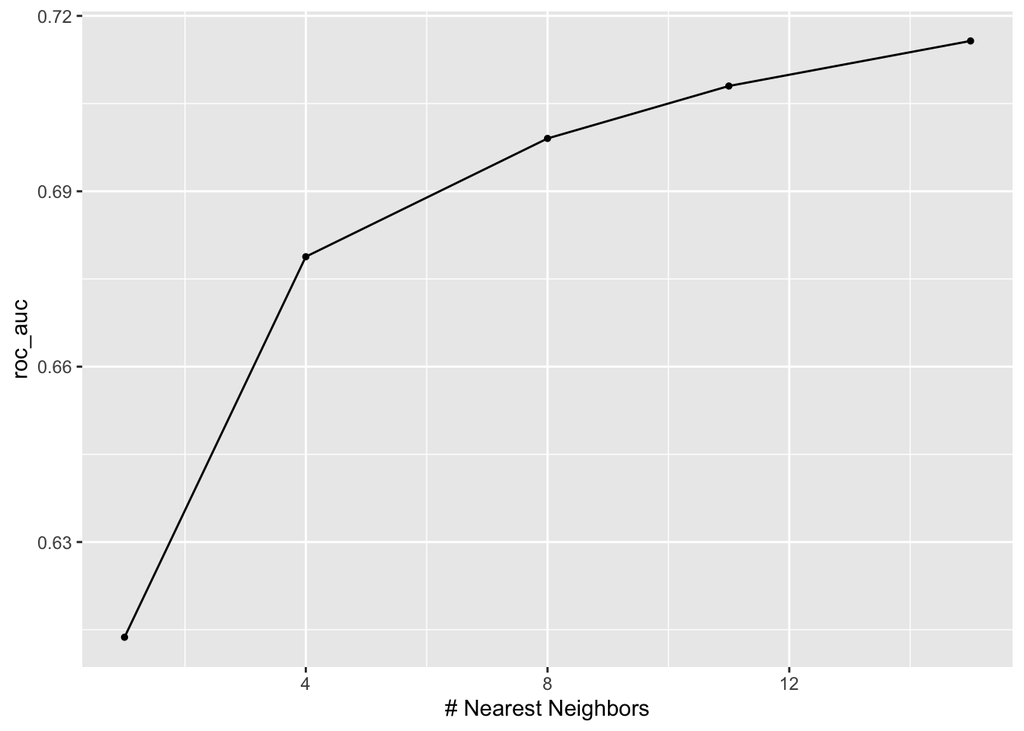

Figure 10: KNN Autoplot (Feature-Engineered)

As we can see from Figure 10, the ROC AUC value for the feature-engineered KNN model increases as the number of nearest neighbors increases. This means that the best tuning parameters would have a number of nearest neighbors that is more than 12 (probably around 15).

### Elastic Net tuning parameters:

Let’s take a look at the tuning parameters for the Elastic Net model:

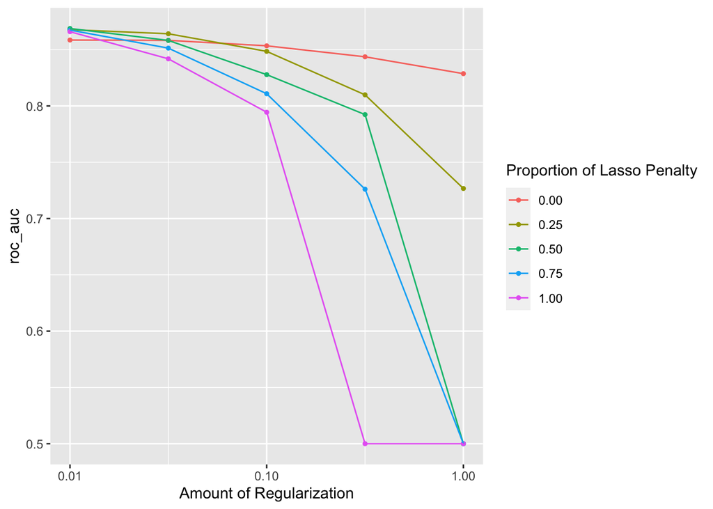

Figure 11: Elastic Net Autoplot

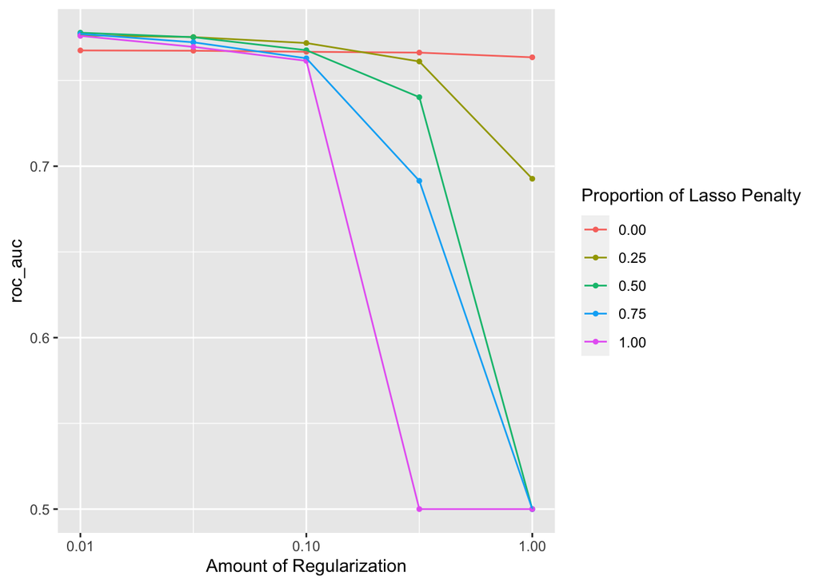

Figure 12: Elastic Net Autoplot (Feature-Engineered)

### Random Forest tuning parameters:

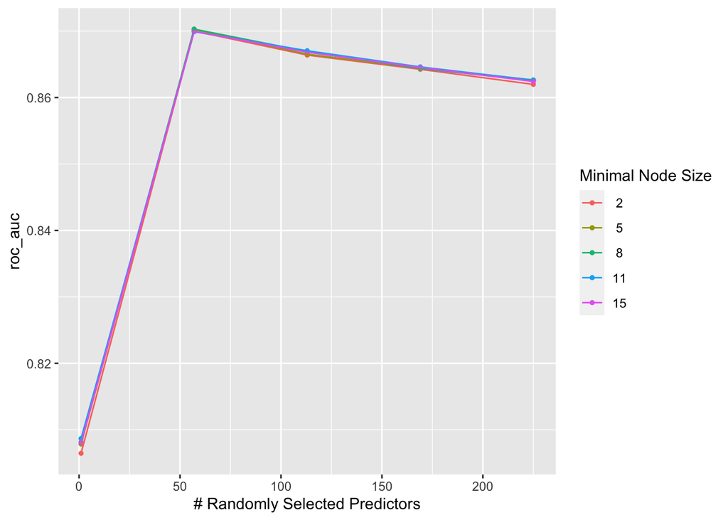

Figure 13: Random Forest Autoplot

As we can see from Figure 13, the ROC AUC value doesn’t seem to differ too much across minimal node size. However, it does seem like the most optimal number of randomly selected predictors would be around 50 since it produced the highest ROC AUC value.

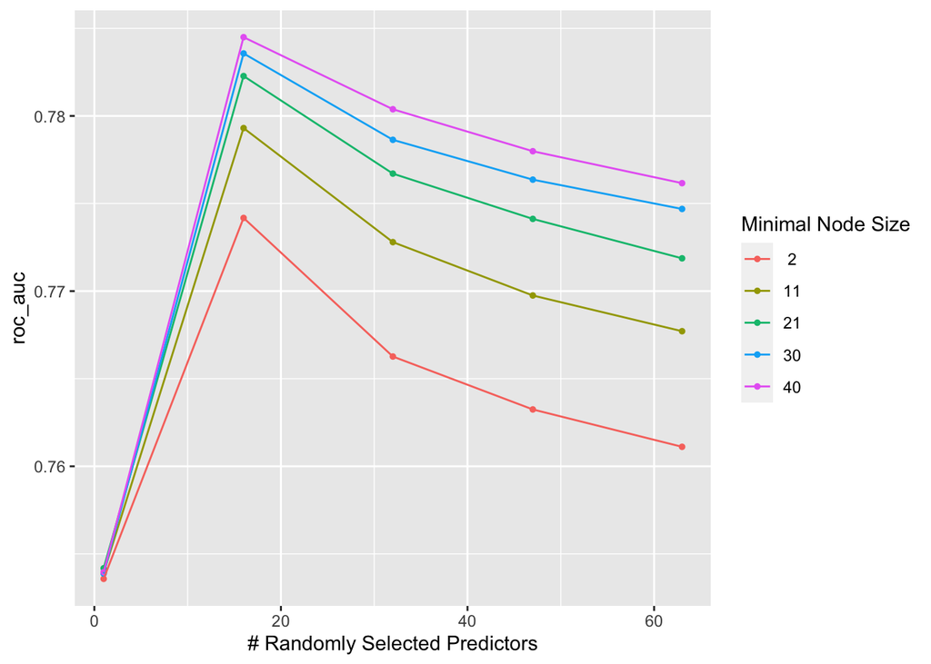

Figure 14: Random Forest Autoplot (Feature-Engineered)

As we can see from Figure 14, the ROC AUC differs quite a lot across minimal node size. As the minimal node size increased, the ROC AUC value tended to also be higher. It also looks like the most optimal number of randomly selected predictors would be around 18 since it produced the highest ROC AUC value.

### Boosted Tree tuning parameters:

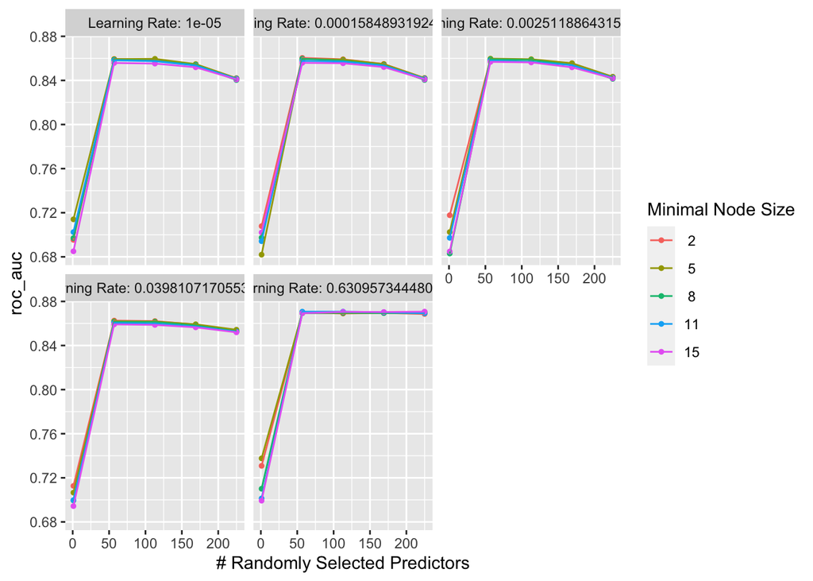

Figure 15: Boosted Tree Autoplot

As we can see from Figure 15, the ROC AUC value doesn’t seem to differ too much across minimal node size. However, it does seem like the most optimal learn rate would be around 0.631 since it generally produced higher ROC AUC values. The ROC AUC values were also best when the number of randomly selected predictors was around 50.

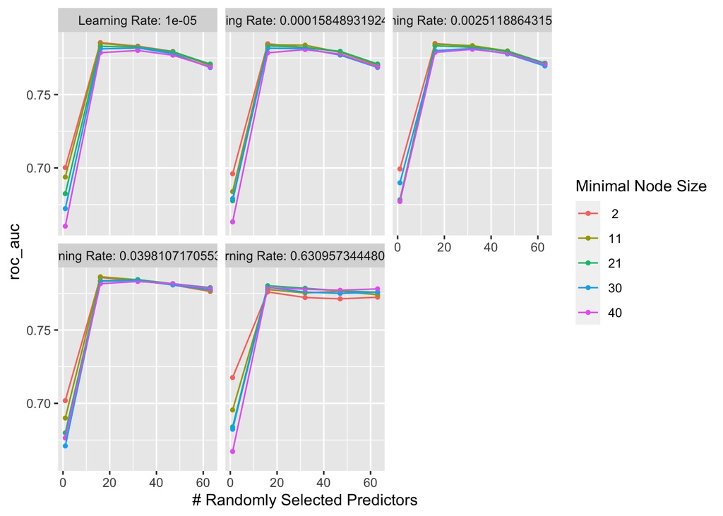

Figure 16: Boosted Tree Autoplot (Feature-Engineered)

As we can see from Figure 16, the ROC AUC value doesn’t seem to differ too much across minimal node size. However, it does seem like the most optimal learn rate would be around 0.0398 since it generally produced higher ROC AUC values. The ROC AUC values were also best when the number of randomly selected predictors was around 18.

## Footnotes

[^1]: Realinho,Valentim, Vieira Martins,Mónica, Machado,Jorge, and Baptista,Luís. (2021). Predict students’ dropout and academic success. UCI Machine Learning Repository. https://doi.org/10.24432/C5MC89.